# Predicting benthic sensitivity

Author

Daniel van Denderen & Jan-Geert Hiddink

## Introduction

This step demonstrates how to predict benthic sensitivity. It is based on the regional grid defined in step 1 and the statitsical model estimated in step 2.

## Install and Load Required Libraries

We first load again the libraries and custom functions.

```r
# Load necessary libraries and custom functions
source("Libraries_needed.R")
source("Functions.R")
```

## Load regional grid and statistical model

We can use the environmental data in each grid cell and the statistical model to predict benthic sensitivity.

```r
# Load grid data from step 1
load("model/region_grid.RData")

# load coefficients from step 2
load("model/Coefficients_Bdata.RData")

coef_int   <- modcoeff[1]
coef_ll    <- modcoeff[2]
coef_Mud   <- modcoeff[3]
coef_Depth <- modcoeff[4]
```

## Predict the longevity - biomass distribution per grid cell

For each grid cell, we can predict the distribution of biomass across species longevity. This allows us not only to estimate the full distribution, but also to derive useful summary measures, such as the median longevity, i.e. the longevity at which 50% of biomass comes from longer-living species.

To estimate longevity at a given cumulative biomass level, we need to follow these steps:

### Rearranging the statistical model

The fitted model has the form:

$Cb \sim ll + \text{Depth} + \text{Sediment}$

where:

- Cb = cumulative biomass (proportion between 0–1)
- ll = log-transformed longevity
- Depth= bottom depth
- Sediment = categorical habitat covariate with two categories (e.g., *other/sand* vs. *mud*). One category (*other/sand*) is the reference. The other (*mud*) enters the equation as a binary indicator variable (0 = other/sand, 1 = mud).

Because the model uses a binomial link, we apply the logit transformation to cumulative biomass:

$\text{logit}(C_b) = \beta0 + \beta_{\text{ll}} \cdot ll + \beta_{\text{Mud}} \cdot \text{Mud} + \beta_{\text{Depth}} \cdot \text{Depth}$

where:

- $\beta_0$ = intercept (coef_int)
- $\beta_{\text{ll}}$ = coefficient for log-longevity (coef_ll)
- $\beta_{\text{Mud}}$ = effect of *mud* sediment relative to *other/sand* (coef_Mud)
- $\beta_{\text{Depth}}$ = coefficient for bottom depth (coef_Depth)

### Solving for longevity

To rearrange for log-longevity:

$ll = ({\text{logit}(Cb) - \beta_0 - \beta_{\text{Mud}} \cdot \text{Mud} - \beta_{\text{Depth}} \cdot \text{Depth}}) / {\beta_{\text{ll}}}$

Finally, back-transform to the original scale:

$\text{longevity} = \exp(ll)$

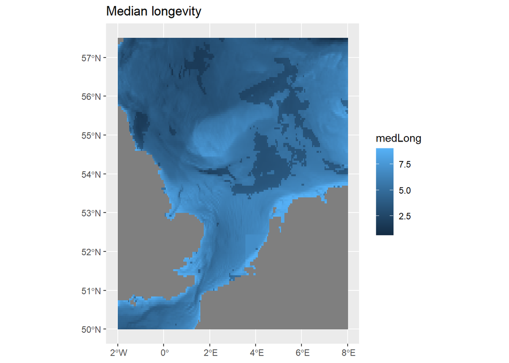

```r
# prepare grid specific information to predict longevity
id_mud <- c("Circalittoral mud","Offshore circalittoral mud","Infralittoral mud")
Mud <- ifelse(grid_sf$Dominant_MSFD %in% id_mud,1,0)
Depth <- grid_sf$Depth

# estimate median longevity, i.e. the longevity at which 50% of biomass comes from longer-living species
grid_sf$medLong <- exp((logit(0.5)- coef_int - coef_Mud*Mud - coef_Depth*Depth) / coef_ll)

# Visualization: median longevity
ggplot() +
  geom_sf(data = grid_sf, aes(col = medLong, fill= medLong)) +
  ggtitle("Median longevity")
```

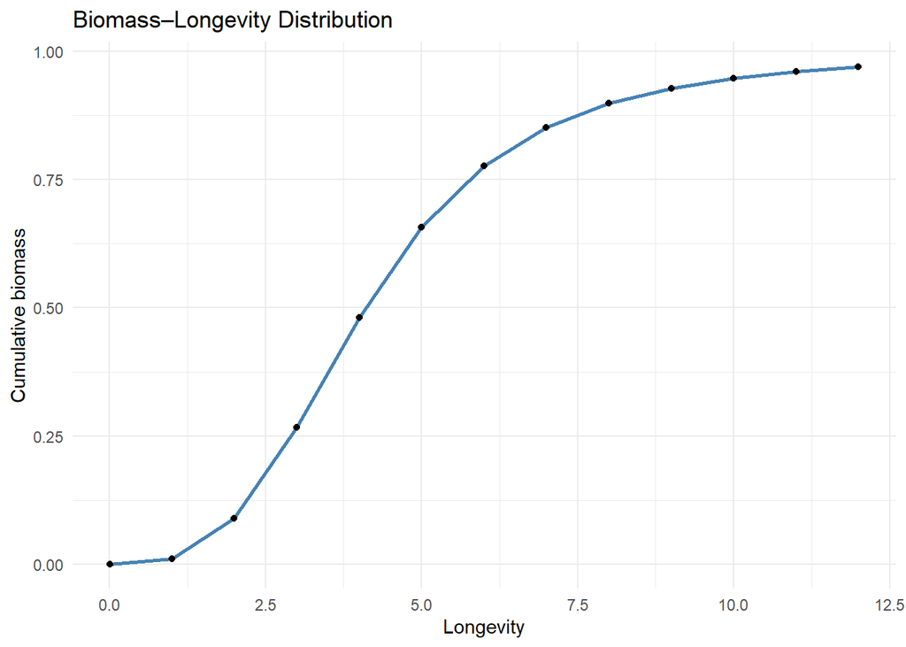

```r
# slope to obtain biomass-longevity distribution
grid_sf$slope     <- rep(coef_ll,nrow(grid_sf))

# intercept to obtain biomass-longevity distribution
grid_sf$intercept <- coef_int + coef_Mud*Mud + coef_Depth*Depth

# make a plot for one grid cell to see how it looks
Longevity <- c(0.01, 1:12)
ll <- log(Longevity)
Cb_pred <- exp(grid_sf$intercept[1] + grid_sf$slope[1] * ll) /
  (1+ exp(grid_sf$intercept[1] + grid_sf$slope[1] * ll))

plot_df <- data.frame(
  Longevity = Longevity,
  Cb = Cb_pred
)

# Plot
ggplot(plot_df, aes(x = Longevity, y = Cb)) +
  geom_line(color = "steelblue", linewidth = 1) +
  geom_point(color = "black") +
  labs(
    x = "Longevity",
    y = "Cumulative biomass",
    title = "Biomass–Longevity Distribution"
  ) +
  theme_minimal()
```

## Save the grid with sensitivity prediction

```r
# Save grid with sensitivity prediction

save(grid_sf, file="model/Region_grid_sensitivity.RData")
```

## Done?

In some cases, there may be an interaction between longevity (ll) and another parameter. For example, the effect of ll on cumulative biomass (Cb) might differ between shallow and deep areas. The intercept and slope of the longevity–biomass relationship will then depend on the interaction term, meaning they vary according to the parameter, such as depth.

Can you re-arrange the equation to get the median longevity? And what would be the intercept and slope of the longevity-biomass distribution?

$$\text{logit}(C_b) = \beta_0 + \beta_{\text{ll}} \cdot ll + \beta_{\text{Mud}} \cdot \text{Mud} + \beta_{\text{Depth}} \cdot \text{Depth} + \beta_{\text{Depth\_ll}} \cdot \text{Depth} \cdot ll$$